# Calculando Betas de empresas na B3

R package build

2021-03-09

Nesse post, calculamos o coeficiente Beta do modelo CAPM de empresas de capital aberto com ações negociadas na B3.

Começamos com o download dos tickers de empresas ativas em março de 2021.

Download tickers.xlsx

A leitura dos tickers é feita com o comando read_excel, do pacote readxl https://readxl.tidyverse.org/

```r
library(readxl)
```

As ações de empresas brasileiras são encontradas no *yahoofinance* com a adição de “.SA” aos tickers. Então, temos que adicionar esse sufixo ao nosso arquivo de tickers, criando a coluna codigo no dataframe *tickers* .

```r
tickers <- read_excel("tickers.xlsx", sheet=1, col_names = TRUE)
tickers$codigo <- paste(tickers$`unique(Dados$Codigo)`,".SA",sep="")
lista <- tickers$codigo
```

A função *tq_get* do pacote tidyquant https://cran.r-project.org/web/packages/tidyquant/index.html, permite a obtenção de preços diários das ações diretamente do https://finance.yahoo.com/, para todos os nossos tickerts. É um processo que pode demorar, dependendo da qualidade da conexão com a internet. No mesmo bloco de código, transformamos os preços diários em retornos logarítmicos ajustados, que são definidos da seguinte forma:

$$LogReturns = \log(\frac{P_{t}+Proventos}{P_{t-1}})$$
O Código para obter as informações de preço ajustado das ações que compõem nossa lista de tickers, bem como da Bovespa, estão nos blocos abaixo:

```r
library(tidyquant)
library(dplyr)
```

```r
log_Retornos_diarios <-   lista %>%
  tq_get(get  = "stock.prices",
         from = "2016-03-01",
         to   = "2021-02-28") %>%
  group_by(symbol) %>%
  tq_transmute(select     = adjusted,
               mutate_fun = periodReturn,
               period     = "daily",
               type = "log",
               col_rename = "Ra")
```

```r
log_Rb <- "^BVSP" %>%
  tq_get(get  = "stock.prices",
         from = "2016-03-01",
         to   = "2021-02-28") %>%
  tq_transmute(select     = adjusted,
               mutate_fun = periodReturn,
               period     = "daily",
               type = "log",
               col_rename = "Rb")
```

Considerando que utilizaremos os dados para calcular os coeficientes betas das empresas brasileiras da B3, faremos a junção do objeto com os retornos das ações com os objetos contendo os retornos do índice IBOVESPA, usando a função dplyr::left_join.

```r
log_Retornos_diarios_indice <- left_join(log_Retornos_diarios, log_Rb, by = c("date" = "date"))
```

Uma inspeção básica do objeto que contem todos os dados:

```r
head(log_Retornos_diarios_indice)
```

```
## # A tibble: 6 x 4
## # Groups:   symbol [1]
##   symbol   date            Ra       Rb
##   <chr>    <date>       <dbl>    <dbl>
## 1 ABCB4.SA 2016-03-01  0       0
## 2 ABCB4.SA 2016-03-02  0.0110  0.0173
## 3 ABCB4.SA 2016-03-03  0.111   0.0500
## 4 ABCB4.SA 2016-03-04  0.0175  0.0393
## 5 ABCB4.SA 2016-03-07 -0.0465  0.00327
## 6 ABCB4.SA 2016-03-08  0.0171 -0.00293
```

Estatísticas básicas por ativo

```r
log_Retornos_diarios_indice  %>%
      group_by(symbol) %>%
      summarise(mean = mean(Ra),
                sd = sd(Ra))%>%
  kable() %>%
  kable_styling(bootstrap_options = c("striped", "hover")) %>%
  scroll_box(width = "100%", height = "200px")
```

| symbol | mean | sd |
| --- | --- | --- |
| AALR3.SA | -0.0006963 | 0.0260096 |
| ABCB4.SA | 0.0007115 | 0.0221484 |
| ABEV3.SA | -0.0000953 | 0.0181864 |
| ADHM3.SA | 0.0001278 | 0.0636089 |
| AELP3.SA | -0.0020204 | 0.0563756 |
| AFLT3.SA | 0.0014006 | 0.0569860 |
| AGRO3.SA | 0.0007313 | 0.0161510 |
| AHEB3.SA | 0.0003763 | 0.0516235 |
| ALPA4.SA | 0.0013674 | 0.0265403 |
| ALUP11.SA | 0.0007635 | 0.0157814 |
| AMAR3.SA | -0.0001853 | 0.0396309 |
| ANIM3.SA | 0.0006608 | 0.0295916 |
| ARZZ3.SA | 0.0012040 | 0.0261843 |
| ATOM3.SA | 0.0002903 | 0.0479180 |
| AZEV4.SA | -0.0002145 | 0.0682829 |
| AZUL4.SA | 0.0006188 | 0.0434166 |
| B3SA3.SA | 0.0013212 | 0.0244079 |
| BAHI3.SA | 0.0008699 | 0.0329942 |
| BALM4.SA | 0.0004811 | 0.0335896 |
| BAUH4.SA | 0.0021086 | 0.0304227 |
| BAZA3.SA | 0.0007831 | 0.0268284 |
| BBAS3.SA | 0.0007331 | 0.0298842 |
| BBDC4.SA | 0.0006720 | 0.0243767 |
| BBRK3.SA | -0.0016293 | 0.0426752 |
| BBSE3.SA | 0.0003117 | 0.0193886 |
| BDLL4.SA | -0.0008971 | 0.0427938 |
| BEEF3.SA | -0.0000939 | 0.0259358 |
| BEES3.SA | 0.0010363 | 0.0195009 |
| BGIP4.SA | 0.0007150 | 0.0246028 |
| BIDI4.SA | -0.0004898 | 0.1289760 |

[output cut: 258 more lines]

Salvamos o objeto gerado até agora no formato rds, nativo do R, para utilização posterior.

```r
saveRDS(log_Retornos_diarios_indice, "log_Retornos_diarios_indice.rds")
```

Para abrir o objeto novamente, é só usar o comando abaixo:

```r
log_Retornos_diarios_indice <-  readRDS("log_Retornos_diarios_indice.rds")
```

Abaixo um exemplo de análise individual, utilizando as ações preferenciais da Petrobras (PETR4)

```r
# Objeto com PETR4
sort(unique(log_Retornos_diarios_indice$symbol))
```

```
##   [1] "AALR3.SA"  "ABCB4.SA"  "ABEV3.SA"  "ADHM3.SA"  "AELP3.SA"  "AFLT3.SA"
##   [7] "AGRO3.SA"  "AHEB3.SA"  "ALPA4.SA"  "ALUP11.SA" "AMAR3.SA"  "ANIM3.SA"
##  [13] "ARZZ3.SA"  "ATOM3.SA"  "AZEV4.SA"  "AZUL4.SA"  "B3SA3.SA"  "BAHI3.SA"
##  [19] "BALM4.SA"  "BAUH4.SA"  "BAZA3.SA"  "BBAS3.SA"  "BBDC4.SA"  "BBRK3.SA"
##  [25] "BBSE3.SA"  "BDLL4.SA"  "BEEF3.SA"  "BEES3.SA"  "BGIP4.SA"  "BIDI4.SA"
##  [31] "BIOM3.SA"  "BKBR3.SA"  "BMEB4.SA"  "BMIN4.SA"  "BMKS3.SA"  "BNBR3.SA"
##  [37] "BOBR4.SA"  "BPAC11.SA" "BPAN4.SA"  "BPHA3.SA"  "BRAP4.SA"  "BRDT3.SA"
##  [43] "BRFS3.SA"  "BRGE8.SA"  "BRIV4.SA"  "BRKM5.SA"  "BRML3.SA"  "BRPR3.SA"
##  [49] "BRSR6.SA"  "BSEV3.SA"  "BSLI4.SA"  "BTOW3.SA"  "BTTL4.SA"  "CALI4.SA"
##  [55] "CAMB4.SA"  "CAML3.SA"  "CARD3.SA"  "CASN4.SA"  "CBEE3.SA"  "CCPR3.SA"
##  [61] "CCRO3.SA"  "CEBR6.SA"  "CEDO4.SA"  "CEEB3.SA"  "CEED4.SA"  "CEGR3.SA"
##  [67] "CEPE5.SA"  "CESP6.SA"  "CGAS5.SA"  "CGRA4.SA"  "CIEL3.SA"  "CLSC4.SA"
##  [73] "CMIG4.SA"  "COCE5.SA"  "CORR4.SA"  "CPFE3.SA"  "CPLE6.SA"  "CRDE3.SA"
##  [79] "CREM3.SA"  "CRFB3.SA"  "CRIV4.SA"  "CRPG5.SA"  "CSAB3.SA"  "CSAN3.SA"
##  [85] "CSMG3.SA"  "CSNA3.SA"  "CSRN6.SA"  "CTKA4.SA"  "CTNM4.SA"  "CTSA3.SA"
```

[output cut: 33 more lines]

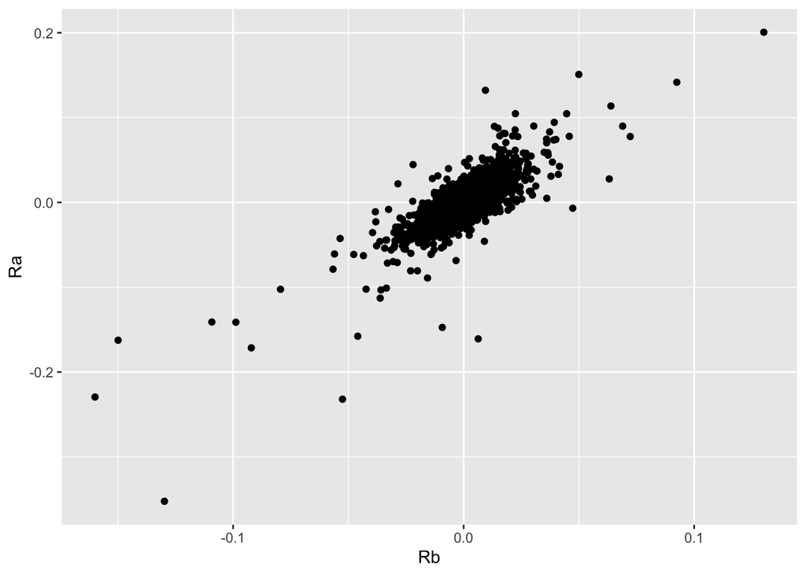

```r
petro <- log_Retornos_diarios_indice %>% dplyr::filter(symbol=="PETR4.SA")

ggplot(petro) + geom_point(aes(x=Rb,y=Ra))
```

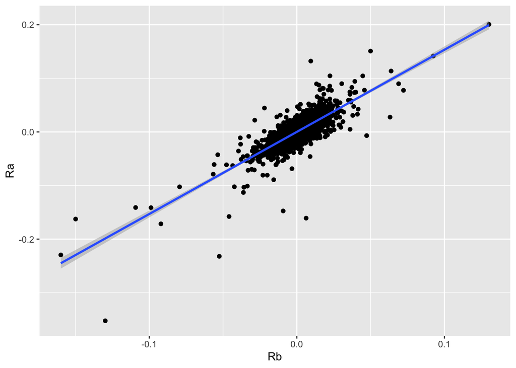

```r
ggplot(petro) + geom_point(aes(x=Rb,y=Ra)) + geom_smooth(aes(x=Rb,y=Ra), method = "lm")
## `geom_smooth()` using formula 'y ~ x'
## Warning: Removed 6 rows containing non-finite values (stat_smooth).

## Warning: Removed 6 rows containing missing values (geom_point).
```

Vamos gerar uma tabela com os coeficientes beta de todas as empresas que fazem parte da nossa lista, e exportar essas informações para o Excel

```r
require(tidyverse)
library(tidyquant)
library(writexl)
library(kableExtra)

log_Retornos_diarios_indice  %>%
  group_by(symbol) %>%
  summarise(mean = mean(Ra),
            sd = sd(Ra),
            beta = coefficients(summary(lm(Ra ~ Rb)))[2])%>%
  arrange(beta) %>%
  kable() %>%
  kable_styling(bootstrap_options = c("striped", "hover")) %>%
  scroll_box(width = "100%", height = "200px")
```

| symbol | mean | sd | beta |
| --- | --- | --- | --- |
| SOND5.SA | 0.0007497 | 0.1870933 | -0.8460217 |
| FBMC4.SA | -0.0015671 | 0.0588299 | -0.2477688 |
| FIBR3.SA | 0.0008386 | 0.0237779 | -0.2428492 |
| PPLA11.SA | NaN | NA | -0.2140846 |
| MMAQ4.SA | 0.0073620 | 0.1664856 | -0.1854531 |
| GPAR3.SA | 0.0023133 | 0.0978167 | -0.1145556 |
| DAGB33.SA | -0.0001322 | 0.0189544 | -0.0957405 |
| PEAB4.SA | 0.0011799 | 0.0251341 | -0.0516118 |
| CASN4.SA | -0.0000767 | 0.0182545 | -0.0404811 |
| MSPA3.SA | 0.0007431 | 0.0234138 | -0.0225305 |
| AHEB3.SA | 0.0003763 | 0.0516235 | -0.0060540 |
| CSAB3.SA | 0.0002197 | 0.0248230 | -0.0053801 |
| MTIG4.SA | 0.0006211 | 0.0377507 | -0.0047000 |
| RSUL4.SA | 0.0017007 | 0.0247659 | -0.0029446 |
| TKNO4.SA | 0.0001081 | 0.0150440 | -0.0023742 |
| CSRN6.SA | 0.0008508 | 0.0125014 | -0.0012378 |
| PPAR3.SA | 0.0000629 | 0.0011658 | -0.0004576 |
| CEGR3.SA | 0.0012838 | 0.0253978 | -0.0001210 |
| FIGE3.SA | 0.0000042 | 0.0000684 | -0.0000269 |
| CORR4.SA | -0.0001174 | 0.0257913 | 0.0015888 |
| CEED4.SA | 0.0008633 | 0.0255614 | 0.0086781 |
| ODER4.SA | 0.0035509 | 0.0559690 | 0.0098670 |
| MERC4.SA | 0.0003688 | 0.0431034 | 0.0123436 |
| LHER4.SA | 0.0003995 | 0.0023637 | 0.0150278 |
| ECPR4.SA | 0.0006035 | 0.0214680 | 0.0161594 |
| NUTR3.SA | 0.0013989 | 0.0608515 | 0.0173080 |
| MRSA6B.SA | 0.0010448 | 0.0312638 | 0.0204805 |
| JOPA3.SA | 0.0009733 | 0.0249401 | 0.0255879 |
| CAMB4.SA | -0.0003938 | 0.0850585 | 0.0273433 |
| ENMT3.SA | 0.0012592 | 0.0294108 | 0.0311586 |

[output cut: 258 more lines]

```r
# Levar para o Excel

arquivo <- log_Retornos_diarios_indice  %>%
  group_by(symbol) %>%
  summarise(mean = mean(Ra),
            sd = sd(Ra),
            beta = coefficients(summary(lm(Ra ~ Rb)))[2])%>%
  arrange(beta)
require(writexl)
write_xlsx(arquivo, "Betas.xlsx")
```